# Data view of the Mental Health Study

Load packages:

```r
library(foreign)
library(psych)
library(car)
library(stringr)
library(ggplot2)
library(likert)
```

# Section SD: Sociodemografics

#### [SD01] Gender “Which gender do you identify with?”

```
  0 = female;
  1 = male;
  NA = diverse, rather not say or Not answered
```

```r
table(dat$SD01, useNA='always' )
```

```
   0    1 <NA>
 355  220   14
```

#### SD02 [age] “How old are you?” SD02_01 I am … years old

```
24: 24 and younger
..: age
34: 34 and older
```

```r
table(dat$age,useNA='always' )
```

```
  24   25   26   27   28   29   30   31   32   33   34 <NA>
  29   52   67   93   74   52   66   48   30   20   53    5
```

#### [SD08] Nationality “What is your nationality?”

- europe: 1=Europe 0=Non-Europe
- german: 1=German, 0=Non-German

```r
table(dat$europe, deparse.level = 2, useNA = "always")
```

```
dat$europe
   0    1 <NA>
  85  488   16
```

```r
table(dat$german, deparse.level = 2, useNA = "always")
```

```
dat$german
   0    1 <NA>
 174  400   15
```

#### [SD10] Family education background “What is your family’s academic background?”

```
  1 = academic (at least one parent/legal guardian has a university degree)
  0 = non-academic (none of my parents/legal guardians has a university degree)
  NA = Not answered
```

```r
table(dat$SD10, useNA = "always")
```

```
   0    1 <NA>
 254  333    2
```

#### [SD11] Formale Bildung (einfach) “Did you move to Tuebingen for your Ph.D.?”

```
  0 = no
  1 = yes, from another place in Germany
  2 = yes, from another country
  NA = Not answered
```

```r
table(dat$SD11, deparse.level = 2, useNA = "always")
```

```
dat$SD11
   0    1    2 <NA>
 235  199  154    1
```

#### [SD13] Care-taking “Do you have a child/a person in your family you have to take care of?”

```
  0 = no
  1 = yes, from another place in Germany
  NA = Not answered
```

```r
table(dat$SD13, deparse.level = 2, useNA = "always")
```

```
dat$SD13
   0    1 <NA>
 536   52    1
```

#### SD14 [living] Living-arrangement “What is your housing situation?”

```
  1: Alone
  2: Together with parents / Together with partner / Together with family
  3: Student accommodation / Shared flat
  NA: not answered
```

```r
table(dat$living, deparse.level = 2, useNA = "always")
```

```
dat$living
   1    2    3 <NA>
 156  261  171    1
```

# Section AP: About your PhD

#### [AP01] Faculty “Which faculty are your studies associated with?”

```
1 = Science
2 = Economic and Social Sciences
3 = Humanities
4 = Others (e.g. Theology, Medicine, Law)
5 = Two faculties
NA = not answered
```

```r
table(dat$faculty, useNA = "always")
```

```
   1    2    3    4    5 <NA>
 334   61   71   50   41   32
```

#### [AP02] Choice of Topic “Did you choose the topic of your Ph.D. yourself?”

```
  0 = no
  1 = yes
  NA = Not answered
```

```r
table(dat$AP02, useNA = "always")
```

```
   0    1 <NA>
 250  306   33
```

#### [AP03] Hours per week Ph.D “How many hours a week do you spend on your Ph.D.?”

```
    AP03_01 ... hours/week
```

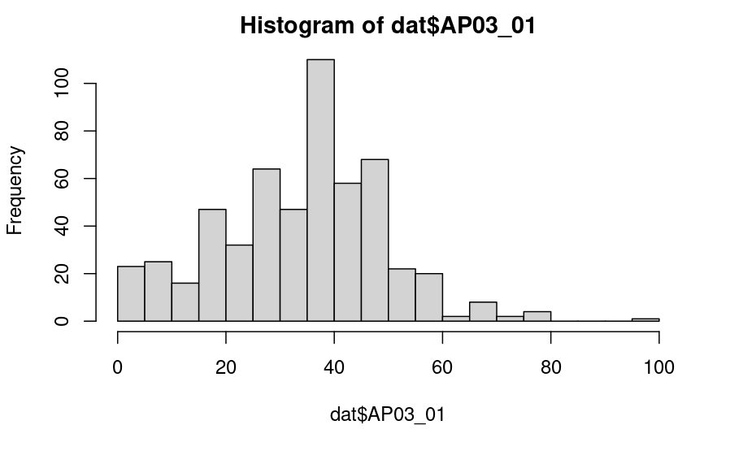

#### [AP05] Hours per week work “How many hours a week do you work in total?”

- AP05_01 … hours/week
- timedif: build difference between phd wporking hours and total working hours

[figure not shown]

#### AP04 [phdstage] Start Ph.D.”When did you start your Ph.D.?”

- phdstage: Time spent as a PhD

  ```
    1 = 0-6 months
    2 = 7-12 months
    3 = 13-18 months
    ...
    9 = 48-54 months
    10 = >54 months
  ```

```r
table(dat$phdstage,useNA = "always")
```

```
   1    2    3    4    5    6    7    8    9   10 <NA>
  51   61   59   72   72   48   54   43   24   56   49
```

# Section EF: Employment/Financial Situation

#### [EF01] Contract Type “How are you financed? (Contract type only related to your Ph.D.)”

```
    1 = Permanent employment
    2 = Temporary employment
    3 = Hourly employment
    6 = Scholarship (employed, paying social security)
    7 = Scholarship (not employed)
    5 = Not employed
    8 = Others
    NA = Not answered
    Remark: if multiple matches in open answers: other
```

```r
table(dat$EF01, useNA = "always")
```

```
   1    2    3    5    6    7    8 <NA>
  45  386    3   38   30   41    8   38
```

#### [EF02] Length of Contract “If you only have a temporary employment: What is the total length of your contract (in months)?”

```
    EF02_01 in months
    12: 0-12
    24: 13-24
    36: 25-36
    48: 37-48
    56: >48
```

```r
table(dat$EF02_01, useNA = "always")
```

```
  12   24   36   48   56 <NA>
  41   43  225   62   21  197
```

#### [EF06] Length of scholarship “If you have a scholarship: What is the total length of your current scholarship (in months)?”

```
    EF06_01 in months
    24: 0-24
    36: 25-36
    48: >36
```

```r
table(dat$EF06_01, useNA = "always")
```

```
  24   36   48 <NA>
  15   41   17  516
```

#### [EF03] % Full time “What is the percentage your contract covers in terms of full-time employment?”

```
    EF03_01 in %
    25: <=25
    50: 26-50
    60: 51-60
    70: 61-70
    80: 71-80
    100: 81-100
```

```r
table(dat$EF03_01)
```

```
 25  50  60  70  80 100
 14 132  26 194  56  39
```

#### [EF04] Other employment “Do you have any other paid employment which is unrelated to your Ph.D.?”

```
    0 = no
    1 = yes
    NA = Now answered
```

```r
table(dat$EF04, useNA = "always")
```

```
   0    1 <NA>
 462   90   37
```

#### [EF05] Reason other employment “Why did you decide to have a side-job?”

```
  ### EF05_01 Earning money/financial reasons
  ### EF05_02 For the CV
  ### EF05_03 Personal interest
  ### EF05_04 Other
  ### 0 = Not checked
  ### 1 = Checked
```

##### TODO: EF05_04a Other, please specify (free text)

see open question procedure.

```r
table(dat$EF05_01, useNA = 'always', dnn = 'EF05_01')
```

```
EF05_01
   0    1 <NA>
  10   78  501
```

```r
table(dat$EF05_02, useNA = 'always', dnn = 'EF05_02')
```

```
EF05_02
   0    1 <NA>
  64   24  501
```

```r
table(dat$EF05_03, useNA = 'always', dnn = 'EF05_03')
```

```
EF05_03
   0    1 <NA>
  53   35  501
```

```r
table(dat$EF05_04, useNA = 'always', dnn = 'EF05_04')
```

```
EF05_04
   0    1 <NA>
  75   13  501
```

# Section EV: Evaluation of your Ph.D.

Summarizing scales:

- Job satisfaction (JS): EV06, EV07, EV08 (Hellgren et al., 1997)

Single scales:

- scale in EV01, EV04, EV06, EV07, EV08

  ```
    1 = strongly disagree
    2 = disagree
    3 = neither agree nor disagree
    4 = agree
    5 = strongly agree
    -1 = not sure
    NA = Not answered
  ```

- [EV01] PhD again “Looking back, if I had not started my Ph.D. yet, I would do it again.”
- [EV04] Regret “I regret having started a Ph.D.”

Please evaluate in the scale the following statements regarding your Ph.D.:

- [EV06] Job-satisfaction1 “I enjoy being at work.”
- [EV07] Job-satisfaction2 “I am content with the job I have.”
- [EV08] Job-satisfaction3 “I am satisfied with my job.”

```r
table(dat$EV01, useNA = "always")
```

```
   1    2    3    4    5 <NA>
  34   61   80  188  136   90
```

#### [EV09] Life-satisfaction “How satisfied are you with your life at the moment?”

```
    1 = not satisfied at all
    2 = slightly satisfied
    3 = moderately satisfied
    4 = very satisfied
    5 = totally satisfied
    NA = Not answered
```

```r
table(dat$EV09, useNA = "always")
```

[output not shown]

#### [EV05] PhD somewhere else “Do you think doing your Ph.D. in/at a different country/university would offer better conditions?”

```
    0 = no;
    1 = yes;
    2 = not sure;
    NA = Not answered
```

```r
table(dat$EV05, useNA = "always")
```

```
   0    1    2 <NA>
 187  135  217   50
```

# Section WG: Structure of working group

#### [WG01] Professional support “Are there colleagues in your department/research center that support you professionally?”

```
    0 = no;
    1 = yes;
    NA = Not answered
```

```r
table(dat$WG01, useNA = 'always')
```

```
   0    1 <NA>
 117  411   61
```

#### [WG02] Emotional support “Are there colleagues in your department/research center that support you emotionally?”

```
    0 = no;
    1 = yes;
    NA = Not answered
```

```r
table(dat$WG02, useNA = 'always')
```

```
   0    1 <NA>
 185  343   61
```

# Section GH: General Health

Summarizing scale:

- Perceived Stress Scale (PSS): GH01, GH02, GH03, GH04 (Cohen, 1984; Büssing, 2011) (GH02 and GH03 are inverted for PSS)

Single scales:

- scale in GH01, GH02, GH03, GH04

  ```
    1 = never
    2 = almost never
    3 = sometimes
    4 = fairly often
    5 = very often
    NA = Not answered
  ```

- [GH01] Stress1 “…how often have you felt that you were unable to control the important things in your life?”
- [GH02] Stress2 “…how often have you felt confident about your ability to handle your personal problems?”
- [GH03] Stress3 “…how often have you felt that things were going your way?”
- [GH04] Stress4 “…how often have you felt difficulties were piling up so high that you could not overcome them?”

```r
table(dat$GH01, useNA = "always")
```

[output not shown]

# Section OR: Other responsibilities

#### [OR01] Reponsibilities besides PhD “What other responsibilities do you have besides working on your research topic/project?”

```
### OR01_01 Teaching
### OR01_02 Supervision of other students
### OR01_03 Administration
### OR01_04 Research unrelated to your topic
### OR01_08 Other, please specify
### OR01_09 No further responsibilities
### 0 = Not checked
### 1 = Checked
```

```r
table(dat$OR01_01, useNA = 'always', dnn = 'OR01_01')
```

```
OR01_01
   0    1 <NA>
 271  252   66
```

```r
table(dat$OR01_02, useNA = 'always', dnn = 'OR01_02')
```

```
OR01_02
   0    1 <NA>
 229  294   66
```

```r
table(dat$OR01_03, useNA = 'always', dnn = 'OR01_03')
```

```
OR01_03
   0    1 <NA>
 301  222   66
```

```r
table(dat$OR01_04, useNA = 'always', dnn = 'OR01_04')
```

```
OR01_04
   0    1 <NA>
 334  189   66
```

```r
table(dat$OR01_08, useNA = 'always', dnn = 'OR01_08')
```

```
OR01_08
   0    1 <NA>
 483   40   66
```

```r
table(dat$OR01_09, useNA = 'always', dnn = 'OR01_09')
```

```
OR01_09
   0    1 <NA>
 449   74   66
```

#### [OR02] Time other responsibilities “How much time do you spend on other responsibilities besides your research activities?”

```
    OR02_01 ... %
```

```r
table(dat$OR02_01,useNA = 'always')
```

```
    1     2   2.5     5   7.5     9    10    12    13    15    17    20  22.5    25
    1     1     1    31     2     1    67     1     1    39     1    71     1    36
   30    35    40    45    50    55    57    60    65 66.67    70    75    80    85
   46     4    24     1    43     3     1    20     2     1    17     7    12     2
   90   100  <NA>
    7     4   141
```

# Section ST: Stressors

Summarizing scales are:

- Job insecurity (JI): ST13, ST14, ST15 (Hellgren et al., 1999)
- Institutional Stressors (supervisor), positive wording (ISpositive): ST02,ST03,ST05,ST07
- Institutional Stressors (supervisor), negative wording (ISnegative): ST01,ST04,ST06,ST08

Individual questions:

#### [ST01] Institutional-stressor1 “Have you ever felt looked down on by your supervisor?”

#### [ST02] Institutional-stressor2 “Do you feel supported by your supervisor?”

#### [ST03] Institutional-stressor3 “Do you feel your supervisor is interested in your topic?”

#### [ST04] Institutional-stressor4 “Have you ever felt mistreated (e.g., insulted, shouted at, undervalued) by your supervisor?”

#### [ST17] Institutional-stressor4_coll “Have you ever felt mistreated (e.g., insulted, shouted at, undervalued) by your colleagues?”

#### [ST05] Institutional-stressor5 “Does your supervisor encourage you to participate in career-building opportunities such as conferences, summer schools, research stays, etc.?”

#### [ST06] Institutional-stressor6 “Based on your experiences in academia so far, do you reconsider your career path?”

#### [ST07] Institutional-stressor7 “Do you feel comfortable contacting your supervisor when you need help?”

#### [ST08] Institutional-stressor8 “Has the behavior of your supervisor ever made you consider quitting your Ph.D.?”

#### [ST09] Institutional-stressor9 “Do you have regular meetings with your supervisor(s)?”

```
    Scale for [ST01] to [ST09] and [ST17]:
    1 = not at all
    2 = rarely
    3 = some of the time
    4 = most of the time
    5 = all of the time
    NA = Not answered
```

```r
table(dat$ST01, useNA = "always")
```

```
   1    2    3    4    5 <NA>
 239  128   82   46   19   75
```

#### [ST16] Institutional-stressor10 “How often do you have meetings with your supervisor(s)?”

```
    1 = at least once a week
    2 = at least once a month
    3 = at least every three months
    4 = at least every six months
    5 = at least once a year
    6 = less than once a year
    NA = Not answered
```

```r
table(dat$ST16, useNA = 'always')
```

```
   1    2    3    4    5    6 <NA>
 133  187   99   62   21   10   77
```

#### [ST11] Systemic-stressor1 “The lack of permanent/long-term contracts in academia worries me.”

#### [ST12] Systemic-stressor2 I believe having a Ph.D. will help me to find a good job.””

#### [ST13] Job-insecurity1 “Please evaluate in the scale the following statements regarding your Ph.D.: “I am worried about having to leave my job before I would like to.”

#### [ST14] Job-insecurity2 “There is a risk that I will have to leave my present job in the year to come.”

#### [ST15] Job-insecurity3 “I feel uneasy about losing my job in the near future.”

```
    Scale for [ST11] to [ST15]
    1 = strongly disagree
    2 = disagree
    3 = neither agree nor disagree
    4 = agree
    5 = strongly agree
    NA = Not answered
```

```r
table(dat$ST11)
```

```
  1   2   3   4   5
 16  37  48 115 296
```

# Section MH: Mental Health

#### [MH01] Mental health 1 “How often do you feel stressed since you have started your Ph.D.?”

```
    1 = not at all
    2 = rarely
    3 = some of the time
    4 = most of the time
    5 = all of the time
    NA = Not answered
```

```r
table(dat$MH01, useNA = 'always')
```

```
   1    2    3    4    5 <NA>
   1   24  212  227   37   88
```

#### [MH02] Mental health 2 “Has your stress level increased since you started your Ph.D.?”

```
    0 = No
    1 = Yes
```

```r
table(dat$MH02, useNA = 'always')
```

```
   0    1 <NA>
 118  383   88
```

#### [MH03] Mental health 3 “What is/are the cause(s) of your stress?”

##### TODO: [MH03_01]: include open answer preprocessing.

#### [MH04] Mental health 4 “Do you have anyone at your institute to consult about your work-related stress?”

```
    MH04_01 Nobody
    MH04_02 Colleagues
    MH04_03 Admins / Coordination
    MH04_04 Supervisor
    MH04_05 Other, please specify
    0 = Not checked
    1 = Checked
```

##### TODO: MH04_05a: Other, please specify (free text). See open answer preprocessing

```r
table(dat$MH04_01, useNA = 'always')
```

```
   0    1 <NA>
 370  132   87
```

#### [MH05] Mental health 5 “Do you feel your mental health has declined due to the Ph.D.?”

```
    1 = not at all
    2 = somehow
    3 = plenty
    4 = severely
    NA = Not answered
```

```r
table(dat$MH05, useNA = 'always')
```

```
   1    2    3    4 <NA>
 121  201  111   66   90
```

#### [MH06] Mental health 6 “What would need to change to improve your mental health status?”

##### TODO: MH06_01 Free Text: include open answer preprocessing

#### [MH07] Mental health 7 “Do you know other Ph.D. students who are struggling with their mental health?”

```
    1 = nobody
    2 = some
    3 = many
    4 = most
    5 = all
    NA = Not answered
```

```r
table(dat$MH07, useNA = 'always')
```

```
   1    2    3    4    5 <NA>
  56  213  132   87   10   91
```

#### [MH08] Mental health 8 “Do you think your mental health problems negatively affect your quality of work?”

```
    1 = never
    2 = almost never
    3 = sometimes
    4 = fairly often
    5 = very often
    NA = Not answered
```

```r
table(dat$MH08, useNA = 'always')
```

```
   1    2    3    4    5 <NA>
  31   75  189  126   75   93
```

#### [MH09] Mental health 9 “Do you think that some special services (e.g., time management courses, coaching, etc.) or structural changes are necessary?”

```
    MH09_01 no
    MH09_02 personalised coaching
    MH09_03 mentoring
    MH09_04 time management courses
    MH09_05 stress management courses
    MH09_08 structural changes
    MH09_09 Other, please specify
    0 = Not checked;
    1 = Checked
    MH09_09a Other, please specify (free text)
```

##### TODO: MH09_09a: open answer

```r
table(dat$MH09_02)
```

```
  0   1
344 155
```

#### [MH10] Psychotherapy “Are you currently in psychotherapy?”

```
    0 = no;
    1 = yes;
    NA = Not answered
```

```r
table(dat$MH10, useNA = 'always')
```

```
   0    1 <NA>
 420   77   92
```

#### [MH11] Diagnosis “Have you ever been diagnosed with a mental disorder?”

```
    0 = no;
    1 = yes;
    NA = Not answered
```

```r
table(dat$MH11, useNA = 'always')
```

```
   0    1 <NA>
 398   99   92
```

## PHQ2 and GAD7

Summarizing scales are:

- Perceived Health Questionaire (PHQ2): (MH12,MH14) (Bach et al.)
- General Anxiety Disorder (GAD7): (MH15,MH16,MH17,MH18,MH19,MH20,MH21) (Bach et al.)

Individual questions:

#### [MH12] PHQ_2_1 “Little interest or pleasure in doing things”

#### [MH16] PHQ_9_1 “Being so restless that it’s hard to sit still”

#### [MH17] PHQ_9_2 “Being tired easily”

#### [MH18] PHQ_9_3 “Muscle tension or muscle pain”

#### [MH19] PHQ_9_4 “Trouble falling asleep or sleeping through”

#### [MH20] PHQ_9_5 “Trouble concentrating, e.g., on reading or watching TV”

#### [MH21] PHQ_9_6 “Becoming easily annoyed or irritable”

#### [MH14] PHQ_2_2 “Feeling down, depressed or hopeless”

```
    same scale for  'MH12', 'MH14','MH15','MH16','MH17','MH18','MH19','MH20','MH21'
    0 = Not at all
    1 = Several days
    2 = More than half the days
    3 = Nearly every day
    NA = Not answered
```

#### [MH15] PHQ_9_Filter “Feeling nervous, anxious, or on edge?”

```
  scale for  [MH15]
  0 = Not at all
  1 = Several days
  2 = More than half the days
  NA = Not answered
```

```r
table(dat$MH12, useNA = "always")
```

```
   0    1    2    3 <NA>
 106  266   76   59   82
```

# Section SH: Seeking Help

#### [SH01] Seeking-help1 “Have you already tried to improve your situation?”

```
    1 = never
    2 = almost never
    3 = sometimes
    4 = fairly often
    5 = very often
    NA = Not answered
```

```r
table(dat$SH01, useNA = 'always')
```

```
   1    2    3    4    5 <NA>
  18   40  196  177   62   96
```

#### [SH02] Seeking-help2 “Have you heard of the consultation services at the university?”

```
    0 = no;
    1 = yes;
    NA = Not answered
```

```r
table(dat$SH02, useNA = 'always')
```

```
   0    1 <NA>
 226  272   91
```

#### [SH04] Seeking-help3 “How much do you know about the consultation services at the university?”

```
    1 = nothing
    2 = almost nothing
    3 = something
    4 = plenty
    5 = a lot
    NA = Not answered
```

```r
table(dat$SH04, useNA = 'always')
```

```
   1    2    3    4    5 <NA>
  12   92  117   40   11  317
```

#### [SH05] Seeking-help4 “Have you sought help from a specialist?”

```
    0 = no;
    1 = yes;
    NA = Not answered
```

```r
table(dat$SH05, useNA = 'always')
```

```
   0    1 <NA>
 352  145   92
```

#### [SH10] Corona “Did the Covid-19 pandemic affect your general situation?”

```
    1 = yes, it improved my general situation
    2 = yes, it worsened my general situation
    3 = yes, but it neither worsened nor improved my general situation
    4 = no
    NA = Not answered
```

```r
table(dat$SH10, useNA = 'always')
```

```
   1    2    3    4 <NA>
  40  247  168   42   92
```

#### [SH06] Seeking-help5 “Do you have anyone to talk to about your issues?”

```
    0 = no;
    1 = yes;
    NA = Not answered
```

```r
table(dat$SH06, useNA = 'always')
```

```
   0    1 <NA>
  48  447   94
```

#### [SH07] Seeking-help6 “What could be done to improve your situation? Feel free to express your opinion and feelings here.”

```
    SH07_01 [01] Free text
```

##### TODO: SH07_01: open question

#### [SH09]Seeking-help7 “Do you have any further comments?”

```
    SH09_01 [01] Free text
```

##### TODO: SH09_01: open question

#### [SH11] Corona2 “Do you think the answers you have provided in this survey have been affected by the Covid-19 pandemic?”

```
    1 = Very likely
    2 = Likely
    3 = Neutral
    4 = Not likely
    5 = Very unlikely
    NA = Not answered
```

```r
table(dat$SH11, useNA = 'always')
```

```
   1    2    3    4    5 <NA>
  69  128  111  119   66   96
```

# Section CO: Informed consent

#### [CO05] Consent: Residual option (negative) or number of selected options

CO05_01 I have been informed about the study and the procedure. I hereby agree to the collection and processing of my above-mentioned data. Consequently, I would like to voluntarily participate in this study. 0 = Not checked; 1 = Checked

```r
table(dat$CO05, useNA = 'always')
```

```
   1 <NA>
 589    0
```

#### [CO07] ConfirmationPHD: Residual option (negative) or number of selected options

CO07_01 I hereby confirm, that I am a Ph.D. student at the University of T?bingen. 0 = Not checked; 1 = Checked

```r
table(dat$CO07_01, useNA = 'always')
```

```
   1 <NA>
 589    0
```

END